# Carrying capacity results

mauricio

2/27/2021

# 1. Scenarios

In this section, we test how grouping stocks by their carrying capacity affect the profits, biomass and effort allocation. We are considering 3 species/fish have a medium carrying capacity (K = 100), and 2 species/fish with higher carrying capacity (K = 300) at time zero.

We considered 3 arrangement for the quota baskets:  
- *Species with similar K:* we have a QB of normal K and a group of high K.  
- *The normal K species predominates in a basket:* we have a QB were the “normal K” species predominates (2 normal K and 1 high K), and the other basket has the remaining species (1 normal K and 1 high K).  
- *The high K species predominates in a basket:*we have a QB were the “high K” species predominates (1 normal K and 2 high K), and the other basket has the remaining species (2 normal K).

We are going to compare these arrangements in terms of biomass, efforts, ant total profits.

## 1.1 Parameters

| Species | r | K | Starting stock (X) | price |
| --- | --- | --- | --- | --- |
| 1 | 0.2 | 100 | 50 | 20 |
| 2 | 0.2 | 100 | 50 | 20 |
| 3 | 0.2 | 100 | 50 | 20 |
| 4 | 0.2 | 300 | 50 | 20 |
| 5 | 0.2 | 300 | 50 | 20 |

| Tech | q1 | q2 | q3 | q4 | q5 | cost |
| --- | --- | --- | --- | --- | --- | --- |
| 1 | 0.04 | 0.01 | 0.01 | 0.01 | 0.01 | 1 |
| 2 | 0.01 | 0.04 | 0.01 | 0.01 | 0.01 | 1 |
| 3 | 0.01 | 0.01 | 0.04 | 0.01 | 0.01 | 1 |
| 4 | 0.01 | 0.01 | 0.01 | 0.04 | 0.01 | 1 |
| 5 | 0.01 | 0.01 | 0.01 | 0.01 | 0.04 | 1 |

# 2. Biomass

## 2.1 Biomass per species

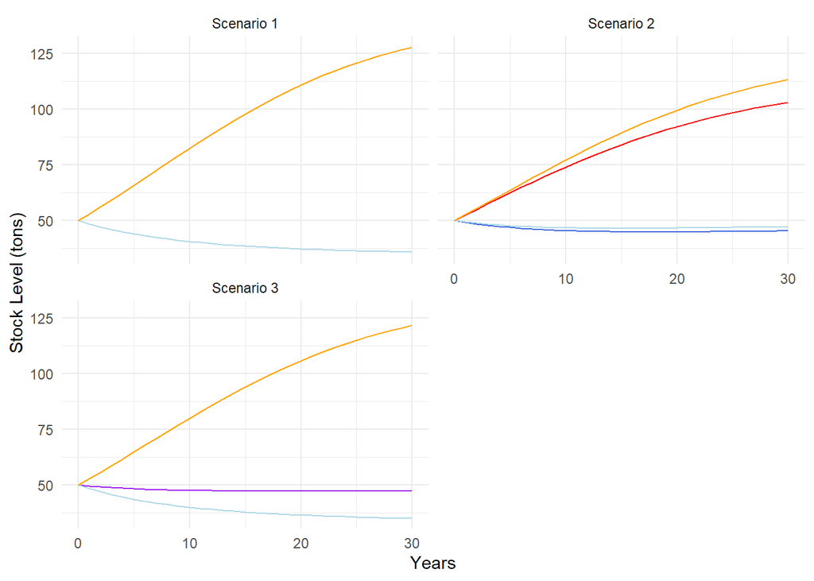

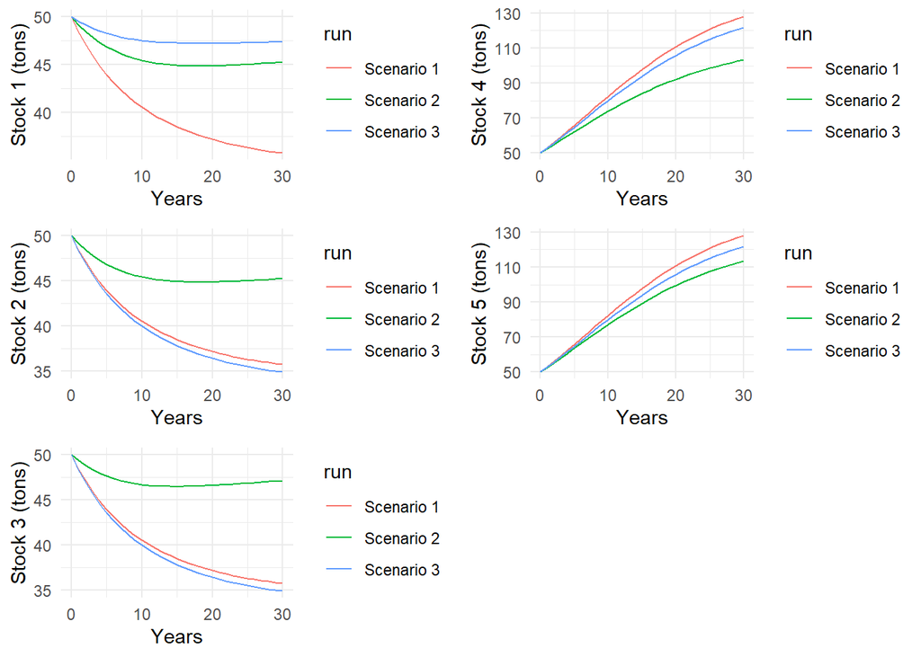

- Holding the rest of the variables constants, grouping only species with low K lead to its stock reduction.  
- In all the scenarios, high K species increase over time. A basket of only high K species, provide the best results. Baskets where high k species are not dominant, provide the worst results but their stocks still increase.  
- The results for the low k stocks improve if they are combined with high k stocks in the same basket.

## 2.2 Total biomass in the ocean

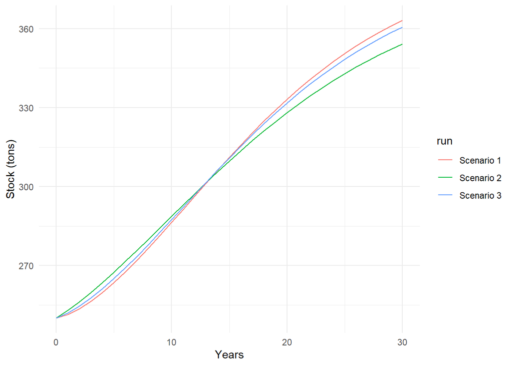

- Combined baskets provide better total stocks in the short term, but baskets with dominant high k species provide better long term results.

# 3. Effort

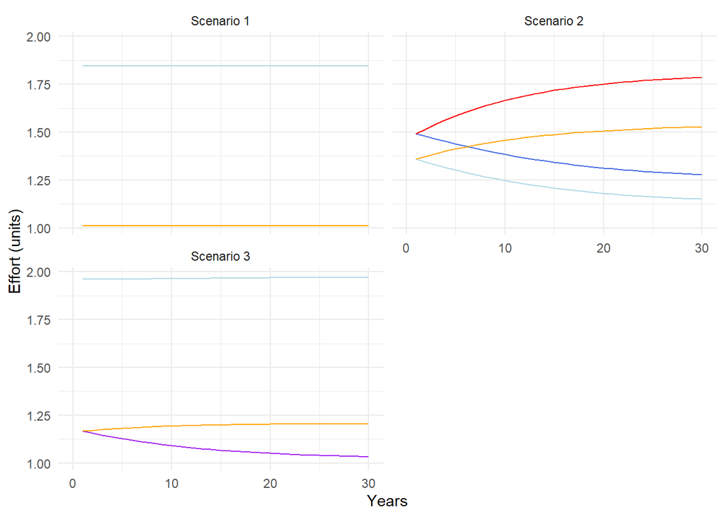

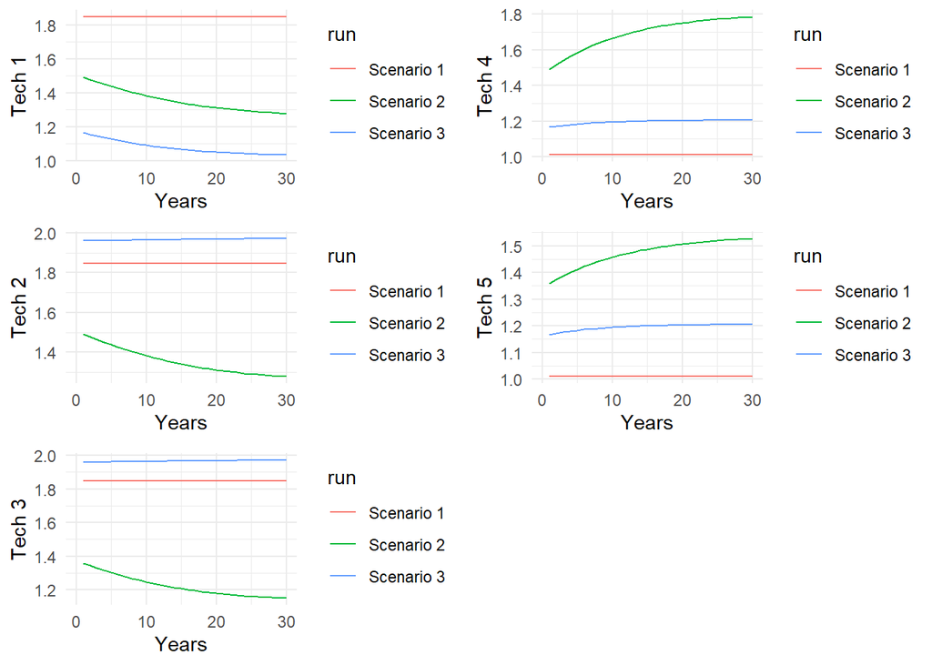

# 4. Profit

# 4.1 Profit per technology

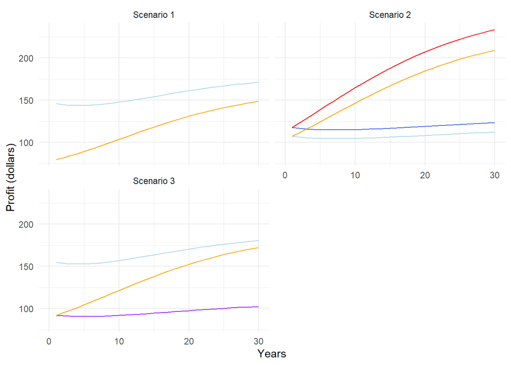

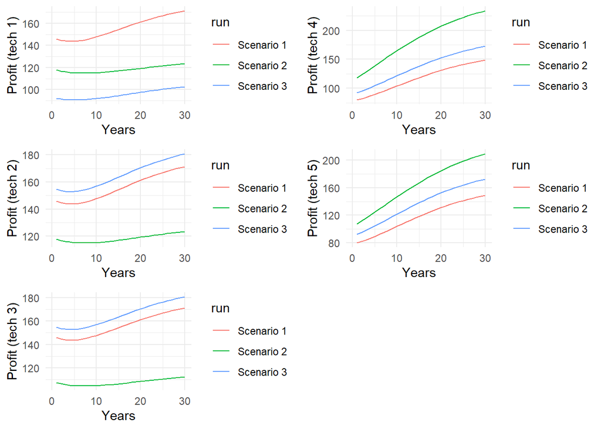

- The profits from tecnologies good at catching low K species increases in baskets with only low K species.  
- The profits from tecnologies good at catching high K species improve in all scenarios, but present better results if they do not dominate any basket.

# 4.2 Total profit per scenario

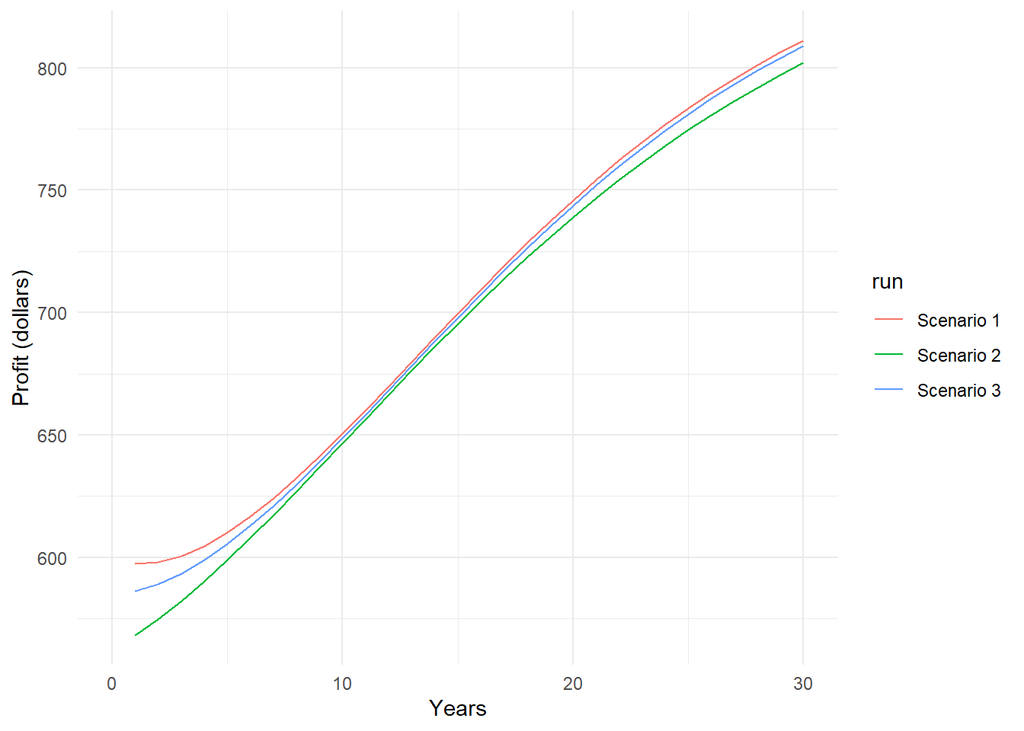

- Scenario 1 has the best results in total profits for all the period of analysis.

# 5. Summary

**Stocks**  
- Holding the rest of the variables constants, grouping only species with low K lead to its stock reduction.  
- In all the scenarios, high K species increase over time. A basket of only high K species, provide the best results. Baskets where high k species are not dominant, provide the worst results but their stocks still increase.  
- The results for the low k stocks improve if they are combined with high k stocks in the same basket.  
- Combined baskets provide better total stocks in the short term, but baskets with dominant high k species provide better long term results.

**Profit**  
- The profits from tecnologies good at catching low K species increases in baskets with only low K species.  
- The profits from tecnologies good at catching high K species improve in all scenarios, but present better results if they do not dominate any basket.  
- Scenario 1 has the best results in total profits for all the period of analysis.